# Projeto IPCA - Grupo 2

Iann Soffried, Lucas Mendes, Rafael Emerick

2025-07-27

# 1 Objetivo

Este projeto tem como objetivo analisar a inflação medida pelo IPCA a partir de diferentes ângulos. A proposta envolve entender a variação entre preços livres e administrados, observar o quanto a inflação está espalhada pela economia por meio do índice de difusão, identificar tendências de longo prazo e construir uma versão dessazonalizada do índice para focar nos movimentos mais estruturais.

# 2 Análise dos Preços Livres e Administrados

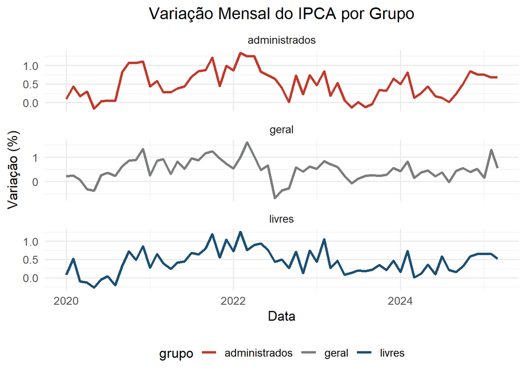

```r
# Importar dados IPCA
ipca_geral <- get_series(433, start_date = "2020-01-01", end_date = "2025-03-01") %>%
  rename(geral = "433")

ipca_livres <- get_series(11427, start_date = "2020-01-01", end_date = "2025-03-01") %>%
  rename(livres = "11427")

ipca_adm <- get_series(11428, start_date = "2020-01-01", end_date = "2025-03-01") %>%
  rename(administrados = "11428")

# Juntar dados
dados <- ipca_geral %>%
  left_join(ipca_livres, by = "date") %>%
  left_join(ipca_adm, by = "date") %>%
  rename(data = date)

# Gráfico Preços Livres, Administrados e Geral
cores_ipca <- c(
  "livres" = "#1B4F72",
  "administrados" = "#C0392B",
  "geral" = "#7B7D7D"
)

dados %>%
  pivot_longer(cols = c(livres, administrados, geral), names_to = "grupo", values_to = "valor") %>%
  ggplot(aes(x = data, y = valor, color = grupo)) +
  geom_line(size = 1.2) +
  facet_wrap(~grupo, ncol = 1, scales = "free_y") +
  scale_color_manual(values = cores_ipca) +
  labs(title = "Variação Mensal do IPCA por Grupo", x = "Data", y = "Variação (%)") +
  theme_minimal(base_size = 13) +
  theme(plot.title = element_text(hjust = 0.5), legend.position = "bottom")
```

> **Análise:** A inflação de preços administrados apresenta maior estabilidade e movimentos abruptos concentrados, refletindo ajustes pontuais em tarifas reguladas. Já os preços livres mostram maior volatilidade, acompanhando mais de perto a dinâmica do IPCA geral. A combinação das duas categorias explica o comportamento composto do índice.

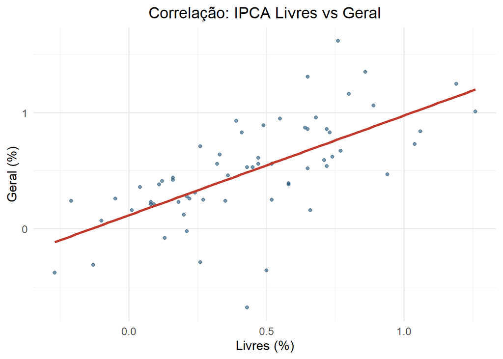

```r
# Gráfico Correlação IPCA Livres vs Geral
ggplot(dados, aes(x = livres, y = geral)) +
  geom_point(color = "#1B4F72", alpha = 0.6) +
  geom_smooth(method = "lm", se = FALSE, color = "#C0392B", size = 1.2) +
  labs(title = "Correlação: IPCA Livres vs Geral", x = "Livres (%)", y = "Geral (%)") +
  theme_minimal(base_size = 13) +
  theme(plot.title = element_text(hjust = 0.5))
```

> **Análise:** A dispersão dos pontos revela uma correlação linear positiva forte entre os preços livres e o IPCA geral. Isso sugere que os preços livres são o principal motor da inflação agregada, o que é esperado dado seu peso na cesta de consumo.

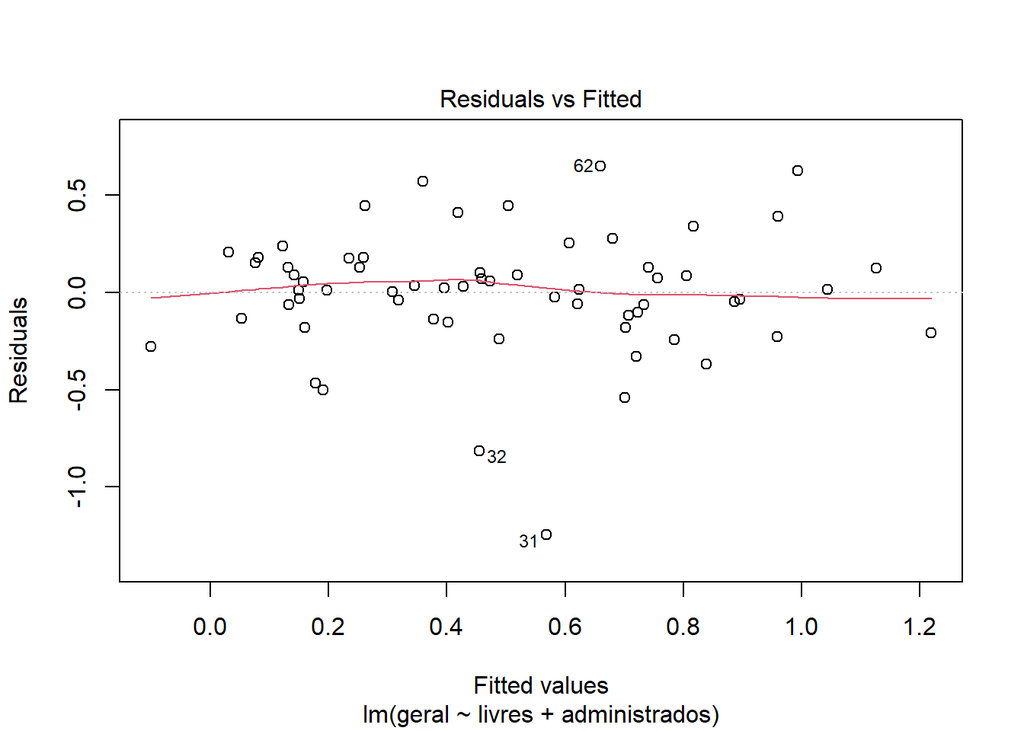

```r
modelo <- lm(geral ~ livres + administrados, data = dados)
summary(modelo)
plot(modelo, which = 1)
```

[output not shown]

> **Análise:** O gráfico de resíduos mostra dispersão relativamente homogênea ao redor de zero, sem padrões sistemáticos evidentes. Isso indica que o modelo linear com preços livres e administrados como variáveis explicativas consegue capturar razoavelmente bem o comportamento do IPCA geral.

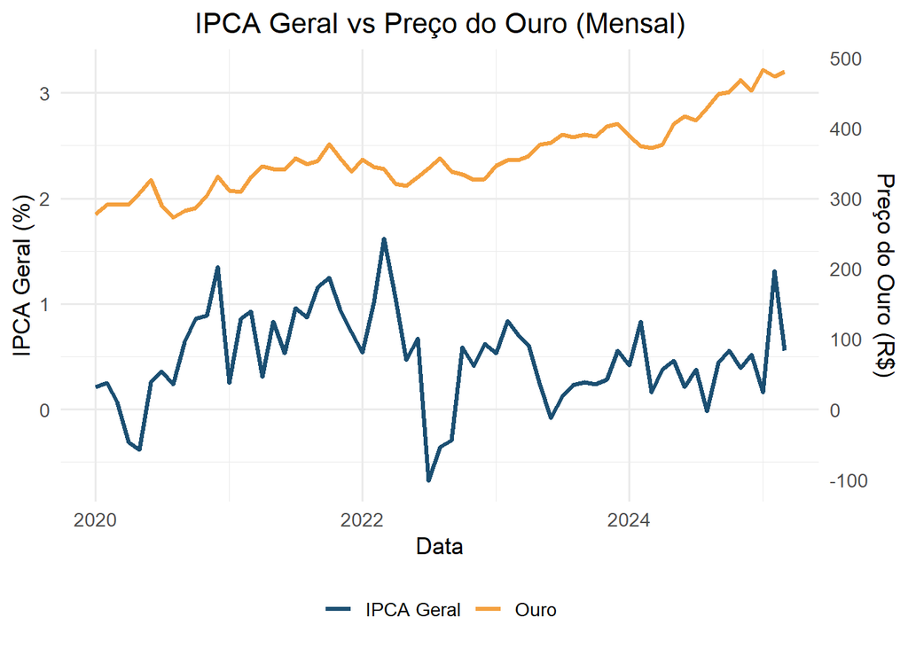

```r
ouro <- read.csv("C:\\Users\\aemer\\OneDrive\\Documentos\\Faculdade\\Econdata Projetos\\Projeto IPCA\\ouro_oz1d_simulado_2020_2025.csv") %>%
  mutate(data = as.Date(data))

ouro_mensal <- ouro %>%
  mutate(mes = floor_date(data, "month")) %>%
  group_by(mes) %>%
  summarise(preco_ouro = mean(oz1d_simulado, na.rm = TRUE), .groups = "drop")

# IPCA e Ouro
ipca_ouro <- dados %>%
  mutate(mes = as.Date(data)) %>%
  left_join(ouro_mensal, by = "mes")

cores_ouro <- c("IPCA Geral" = "#1B4F72", "Ouro" = "#F4A03E")

ggplot(ipca_ouro, aes(x = mes)) +
  geom_line(aes(y = geral, color = "IPCA Geral"), size = 1.2) +
  geom_line(aes(y = preco_ouro / 150, color = "Ouro"), size = 1.2) +
  scale_y_continuous(
    name = "IPCA Geral (%)",
    sec.axis = sec_axis(~ . * 150, name = "Preço do Ouro (R$)")
  ) +
  scale_color_manual(values = cores_ouro) +
  labs(title = "IPCA Geral vs Preço do Ouro (Mensal)", x = "Data", color = NULL) +
  theme_minimal(base_size = 13) +
  theme(plot.title = element_text(hjust = 0.5), legend.position = "bottom")
```

# 3 Análise do Índice de Difusão do IPCA

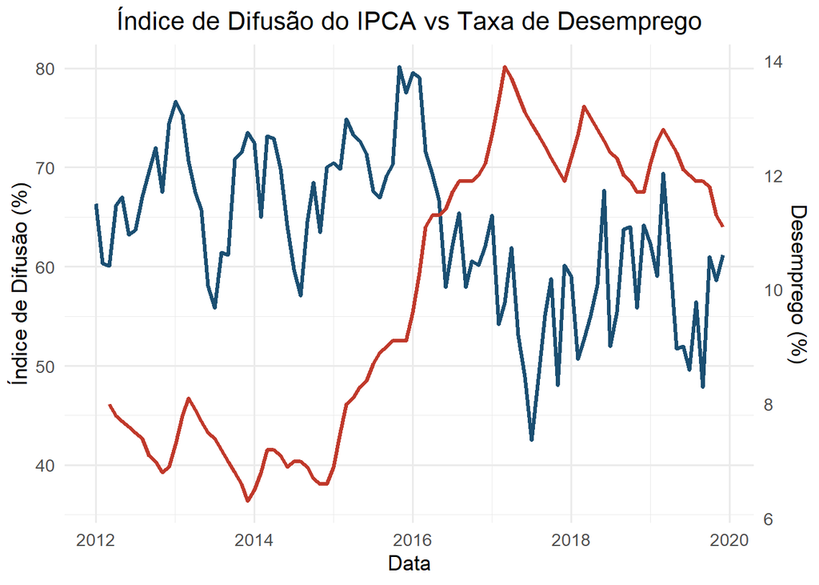

```r
# Coletar variação mensal por subitem do IPCA (Tabela 1419)
ipca_subitens <- get_sidra(api = "/t/1419/n1/all/v/63/p/all/c315/all/d/v63%202") %>%
  select(mes = `Mês (Código)`,
         subitem = `Geral, grupo, subgrupo, item e subitem`,
         variacao = Valor) %>%
  filter(!is.na(variacao)) %>%
  mutate(data = ymd(paste0(mes, "01")))

# Cálculo do índice de difusão
indice_difusao <- ipca_subitens %>%
  group_by(data) %>%
  summarise(
    total_subitens = n(),
    subitens_positivos = sum(variacao > 0),
    indice_difusao = round((subitens_positivos / total_subitens) * 100, 2)
  )

# Coletar série de desemprego mensal
desemprego <- get_series(24369, start_date = "2012-01-01", end_date = Sys.Date()) %>%
  rename(data = date, desemprego = '24369')

# Unir difusão do IPCA e desemprego
painel_macro <- left_join(indice_difusao, desemprego, by = "data")

# Calcular o fator de escala
escala <- max(painel_macro$indice_difusao, na.rm = TRUE) / max(painel_macro$desemprego, na.rm = TRUE)

# Gráfico IPCA e Desemprego
ggplot(painel_macro, aes(x = data)) +
  geom_line(aes(y = indice_difusao), color = "#1B4F72", size = 1.2) +
  geom_line(aes(y = desemprego * escala), color = "#C0392B", size = 1.2) +
  scale_y_continuous(
    name = "Índice de Difusão (%)",
    sec.axis = sec_axis(~ . / escala, name = "Desemprego (%)")
  ) +
  labs(
    title = "Índice de Difusão do IPCA vs Taxa de Desemprego",
    x = "Data"
  ) +
  theme_minimal(base_size = 13) +
  theme(plot.title = element_text(hjust = 0.5))
```

> **Análise:** Em diversos momentos, observa-se uma relação inversa entre a difusão da inflação e o desemprego, alinhando-se à lógica da Curva de Phillips. Períodos de desemprego mais baixo coincidem com maior disseminação da inflação, sugerindo pressões de demanda mais fortes.

# 4 Tendência da Série IPCA

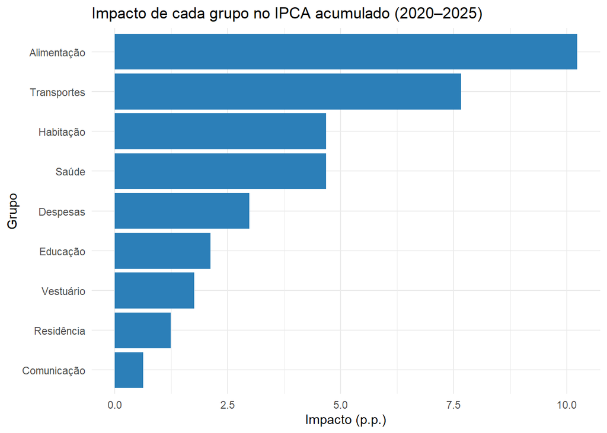

```r
# Baixando as séries dos grupos do IPCA do Banco Central
IPCA = get_series(c(IPCA = 433), start_date = "2020-01-01", end_date = "2025-03-01")

IPCA_Alimentação = get_series(c(IPCA_Alimentação = 1635),
                              start_date = "2020-01-01",
                              end_date = "2025-03-01")

IPCA_Habitação = get_series(c(IPCA_Habitação = 1636),
                            start_date = "2020-01-01",
                            end_date = "2025-03-01")

IPCA_Residência = get_series(c(IPCA_Residência = 1637),
                             start_date = "2020-01-01",
                             end_date = "2025-03-01")

IPCA_Vestuário = get_series(c(IPCA_Vestuário = 1638),
                            start_date = "2020-01-01",
                            end_date = "2025-03-01")

IPCA_Transportes = get_series(c(IPCA_Transportes = 1639),
                              start_date = "2020-01-01",
                              end_date = "2025-03-01")

IPCA_Comunicação = get_series(c(IPCA_Comunicação = 1640),
                              start_date = "2020-01-01",
                              end_date = "2025-03-01")

IPCA_Saúde = get_series(c(IPCA_Saúde = 1641),
                        start_date = "2020-01-01",
                        end_date = "2025-03-01")

IPCA_Despesas = get_series(c(IPCA_Despesas = 1642),
                           start_date = "2020-01-01",
                           end_date = "2025-03-01")

IPCA_Educação = get_series(c(IPCA_Educação = 1643),
                           start_date = "2020-01-01",
                           end_date = "2025-03-01")

# Calculando a variação acumulada

IPCA = mutate(IPCA, VarAcumulada = 100 * (cumprod(1 + IPCA / 100) - 1))

IPCA_Alimentação = mutate(IPCA_Alimentação, VarAcumulada = 100 * (cumprod(1 +
                                                                            IPCA_Alimentação / 100) - 1))

IPCA_Habitação = mutate(IPCA_Habitação, VarAcumulada = 100 * (cumprod(1 +
                                                                        IPCA_Habitação / 100) - 1))

IPCA_Comunicação = mutate(IPCA_Comunicação, VarAcumulada = 100 * (cumprod(1 +
                                                                            IPCA_Comunicação / 100) - 1))

IPCA_Despesas = mutate(IPCA_Despesas, VarAcumulada = 100 * (cumprod(1 +
                                                                      IPCA_Despesas / 100) - 1))

IPCA_Educação = mutate(IPCA_Educação, VarAcumulada = 100 * (cumprod(1 +
                                                                      IPCA_Educação / 100) - 1))

IPCA_Residência = mutate(IPCA_Residência, VarAcumulada = 100 * (cumprod(1 +
                                                                          IPCA_Residência / 100) - 1))

IPCA_Saúde = mutate(IPCA_Saúde, VarAcumulada = 100 * (cumprod(1 + IPCA_Saúde /
                                                                100) - 1))

IPCA_Transportes = mutate(IPCA_Transportes, VarAcumulada = 100 * (cumprod(1 +
                                                                            IPCA_Transportes / 100) - 1))

IPCA_Vestuário = mutate(IPCA_Vestuário, VarAcumulada = 100 * (cumprod(1 +
                                                                        IPCA_Vestuário / 100) - 1))

# Anotando os pesos dos grupos no IPCA, a partir de dados do IBGE de Janeiro de 2018

# Alimentação = 18,99%
# Habitação = 15,16%
# Artigos de residência = 4,02%
# Vestuário = 4,8%
# Transportes = 20,84%
# Saude = 13,46%
# Despesas = 10,6%
# Educação = 5,95%
# Comunicação = 6,19%

# Calculando o impacto de cada grupo no IPCA acumulado

acum_ali = tail(IPCA_Alimentação$VarAcumulada, 1)
acum_hab = tail(IPCA_Habitação$VarAcumulada, 1)
acum_res = tail(IPCA_Residência$VarAcumulada, 1)
acum_ves = tail(IPCA_Vestuário$VarAcumulada, 1)
acum_tra = tail(IPCA_Transportes$VarAcumulada, 1)
acum_sau = tail(IPCA_Saúde$VarAcumulada, 1)
acum_des = tail(IPCA_Despesas$VarAcumulada, 1)
acum_edu = tail(IPCA_Educação$VarAcumulada, 1)
acum_com = tail(IPCA_Comunicação$VarAcumulada, 1)

pesos = c(0.1899,
          0.1516,
          0.0402,
          0.0480,
          0.2084,
          0.1346,
          0.1060,
          0.0595,
          0.0619)
variacoes = c(
  acum_ali,
  acum_hab,
  acum_res,
  acum_ves,
  acum_tra,
  acum_sau,
  acum_des,
  acum_edu,
  acum_com
)
grupos = c(
  "Alimentação",
  "Habitação",
  "Residência",
  "Vestuário",
  "Transportes",
  "Saúde",
  "Despesas",
  "Educação",
  "Comunicação"
)

df_impacto = data.frame(
  Grupo = grupos,
  Peso = pesos,
  Variacao_Acumulada = variacoes,
  Impacto = pesos * variacoes
)

# Analise de impactos

ggplot(df_impacto, aes(x = reorder(Grupo, Impacto), y = Impacto)) +
  geom_col(fill = "#2c7fb8") +
  coord_flip() +
  labs(title = "Impacto de cada grupo no IPCA acumulado (2020–2025)", x = "Grupo", y = "Impacto (p.p.)") +
  theme_minimal()
```

> **Análise:** Apesar de “Alimentação” apresentar tanto o maior impacto acumulado quanto alta volatilidade, a contribuição de cada grupo ao IPCA depende também do peso que possui na estrutura do índice. Por exemplo, grupos como “Comunicação”, mesmo com baixa variação acumulada, também têm impacto reduzido devido à menor participação na composição do IPCA. Assim, maior variação não implica necessariamente maior influência no índice final.

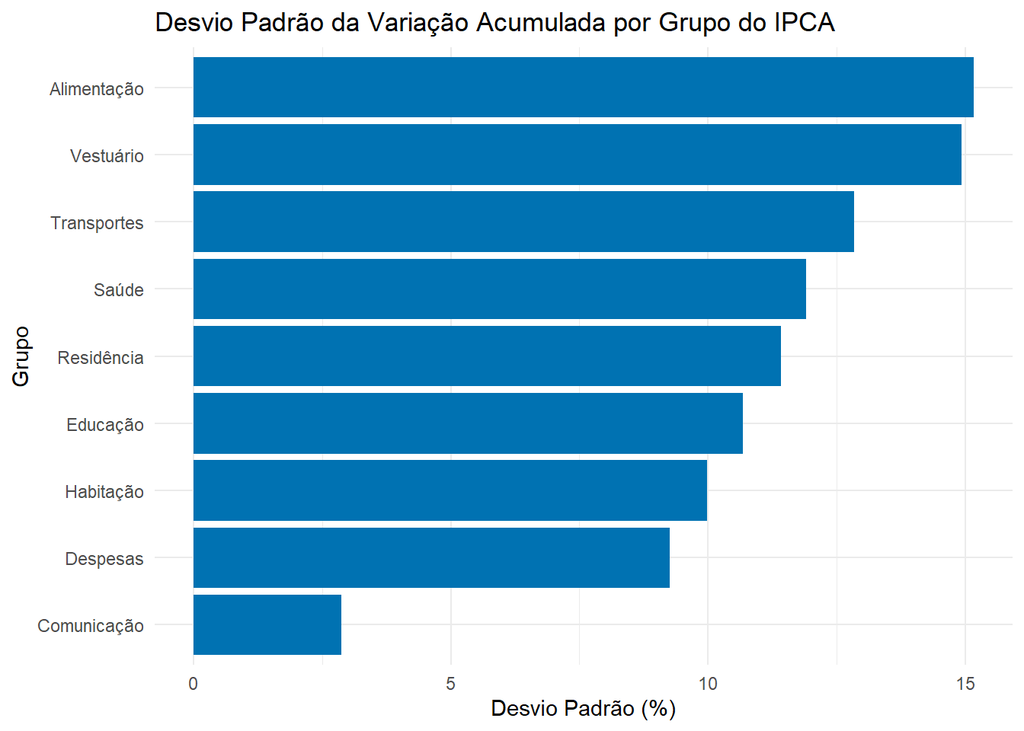

```r
# calcular desvio padrão da variação acumulada

df_desvios <- data.frame(
  Grupo = c(
    "Alimentação",
    "Habitação",
    "Residência",
    "Vestuário",
    "Transportes",
    "Comunicação",
    "Saúde",
    "Despesas",
    "Educação"
  ),
  Desvio_Padrao = c(
    sd(IPCA_Alimentação$VarAcumulada, na.rm = TRUE),
    sd(IPCA_Habitação$VarAcumulada, na.rm = TRUE),
    sd(IPCA_Residência$VarAcumulada, na.rm = TRUE),
    sd(IPCA_Vestuário$VarAcumulada, na.rm = TRUE),
    sd(IPCA_Transportes$VarAcumulada, na.rm = TRUE),
    sd(IPCA_Comunicação$VarAcumulada, na.rm = TRUE),
    sd(IPCA_Saúde$VarAcumulada, na.rm = TRUE),
    sd(IPCA_Despesas$VarAcumulada, na.rm = TRUE),
    sd(IPCA_Educação$VarAcumulada, na.rm = TRUE)
  )
)

# Criar o gráfico de barras dos desvios padrão

ggplot(df_desvios, aes(x = reorder(Grupo, Desvio_Padrao), y = Desvio_Padrao)) +
  geom_bar(stat = "identity", fill = "#0072B2") +
  coord_flip() +
  labs(title = "Desvio Padrão da Variação Acumulada por Grupo do IPCA", x = "Grupo", y = "Desvio Padrão (%)") +
  theme_minimal()
```

> **Análise:** O gráfico mostra que o grupo “Comunicação” apresentou o menor desvio-padrão, indicando maior consistência e estabilidade nas variações acumuladas de preços ao longo do tempo. Já “Alimentação” e “Vestuário” tiveram os maiores desvios, refletindo maior volatilidade. Isso sugere que certos setores são mais suscetíveis a choques específicos ou variações sazonais, enquanto outros mantêm comportamento mais previsível.

# 5 Dessasonalização da Série IPCA

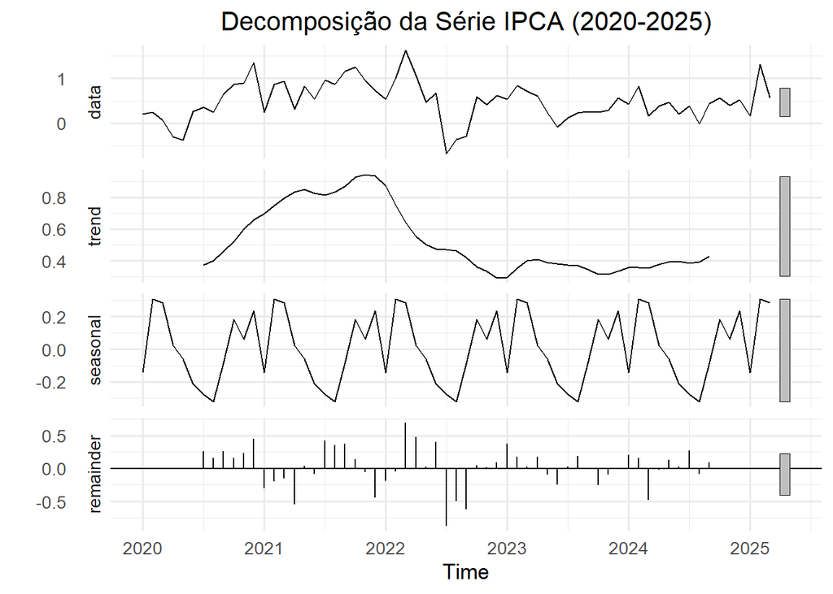

```r
# Paleta personalizada para padronização
cores_dessazonalizacao <- c("ajustada" = "#1B4F72", "original" = "#7B7D7D")

# Baixando a série IPCA do Banco Central
IPCA = get_series(c(IPCA = 433),
                  start_date = "2020-01-01",
                  end_date = "2025-03-01",
                  as = "ts")

# Decompondo a série temporal
dec = decompose(IPCA)

# Plotando a decomposição
autoplot(dec) +
  ggtitle("Decomposição da Série IPCA (2020-2025)") +
  theme_minimal(base_size = 13) +
  theme(plot.title = element_text(hjust = 0.5))
```

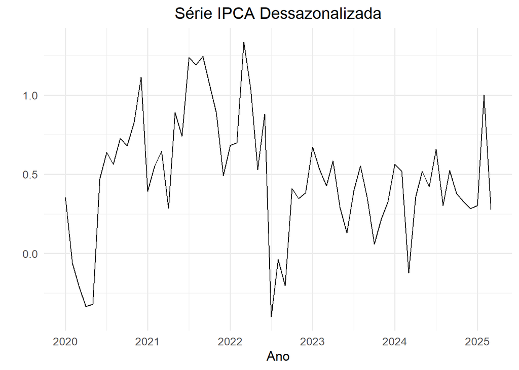

```r
# Dessazonalizando a série
sas = seasadj(dec)

# Plot da série dessazonalizada
autoplot(sas) +
  ggtitle("Série IPCA Dessazonalizada") +
  ylab("") +
  xlab("Ano") +
  theme_minimal(base_size = 13) +
  theme(plot.title = element_text(hjust = 0.5))
```

> **Análise:** A série dessazonalizada evidencia a trajetória real da inflação, suavizando as oscilações mensais e permitindo uma leitura mais precisa dos movimentos de médio prazo da economia.

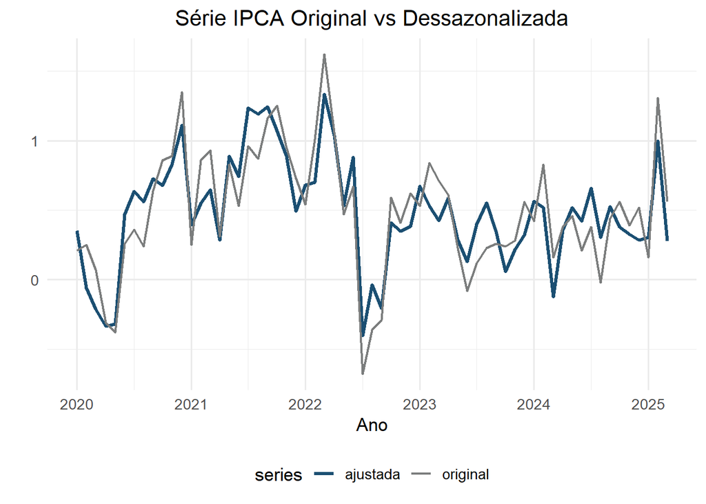

```r
# Plotando série original vs dessazonalizada com legenda correta
autoplot(sas, series = "ajustada", linewidth = 1.2) +
  autolayer(IPCA, series = "original", linewidth = 0.8) +
  scale_color_manual(values = cores_dessazonalizacao) +
  theme_minimal(base_size = 13) +
  labs(x = "Ano", y = "", title = "Série IPCA Original vs Dessazonalizada") +
  theme(plot.title = element_text(hjust = 0.5),
      legend.position = "bottom")
```

> **Análise:** A comparação entre as séries mostra que a dessazonalização preserva a tendência principal da inflação. As diferenças visíveis em picos e vales são pequenas, indicando que o impacto da sazonalidade é moderado, com a maior parte da variação associada a fatores econômicos estruturais.

# 6 Conclusão

O projeto permitiu uma compreensão ampla da dinâmica recente da inflação brasileira, com base em diferentes abordagens sobre o IPCA. A partir da análise entre preços livres e administrados, observou-se que os preços livres desempenham papel central na formação do índice geral, apresentando maior volatilidade e sensibilidade à conjuntura econômica, enquanto os preços administrados se mostraram mais estáveis e sujeitos a ajustes pontuais.

Ao investigar o índice de difusão, foi possível perceber momentos em que a inflação se disseminou de forma mais ampla entre os itens da cesta, especialmente em contextos de recuperação econômica e queda do desemprego. Esse comportamento reforça a relação entre pressão inflacionária e atividade econômica, alinhando-se à lógica da Curva de Phillips.

A dessazonalização da série IPCA trouxe maior clareza à tendência de fundo da inflação, ao remover variações temporárias recorrentes. A análise revelou que os movimentos estruturais predominam sobre os efeitos sazonais, tornando a série ajustada uma ferramenta valiosa para o monitoramento de médio e longo prazo.

De forma integrada, os resultados evidenciam a importância de se analisar não apenas o valor agregado da inflação, mas também sua composição, dispersão e comportamento ao longo do tempo. Essa leitura mais profunda do IPCA contribui para uma interpretação mais precisa dos ciclos inflacionários e fornece subsídios relevantes para decisões econômicas e de política monetária.